# ggplot2_solutions_chapter6

On the other hand, we can try continuous scale on discrete variables:

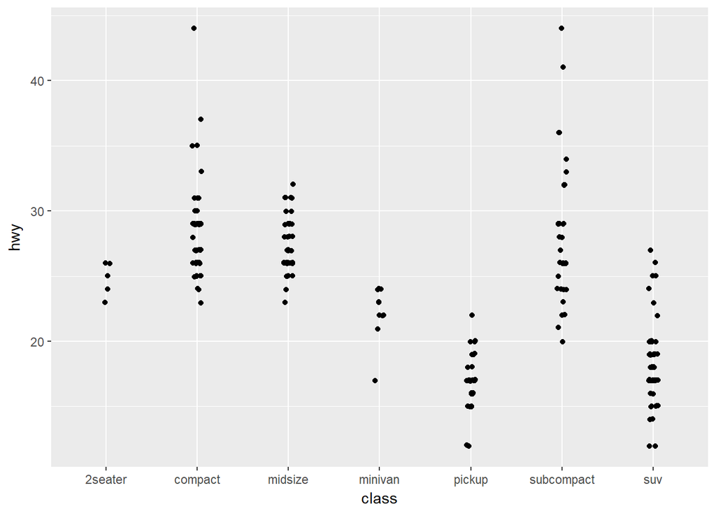

```r
ggplot(mpg, aes(class, hwy)) +
  geom_jitter(width = 0.05, height = 0.05)
```

Now we change the scale on the previous plot:

```r
ggplot(mpg, aes(class, hwy)) +
  geom_jitter(width = 0.05, height = 0.05) +
  scale_x_continuous()
# Error: Discrete value supplied to continuous scale
```

We were not allowed to do so because of the error message: Discrete value supplied to continuous scale.

So in conclusion, we could supply discrete scale to continuous variables, but not vice versa.

*Question 2* Simplify the following plot specifications to make them easier to understand.

```r
ggplot(mpg, aes(displ)) +
scale_y_continuous("Highway mpg") +
scale_x_continuous() +
geom_point(aes(y = hwy))
```

The codes can be simplified as below:

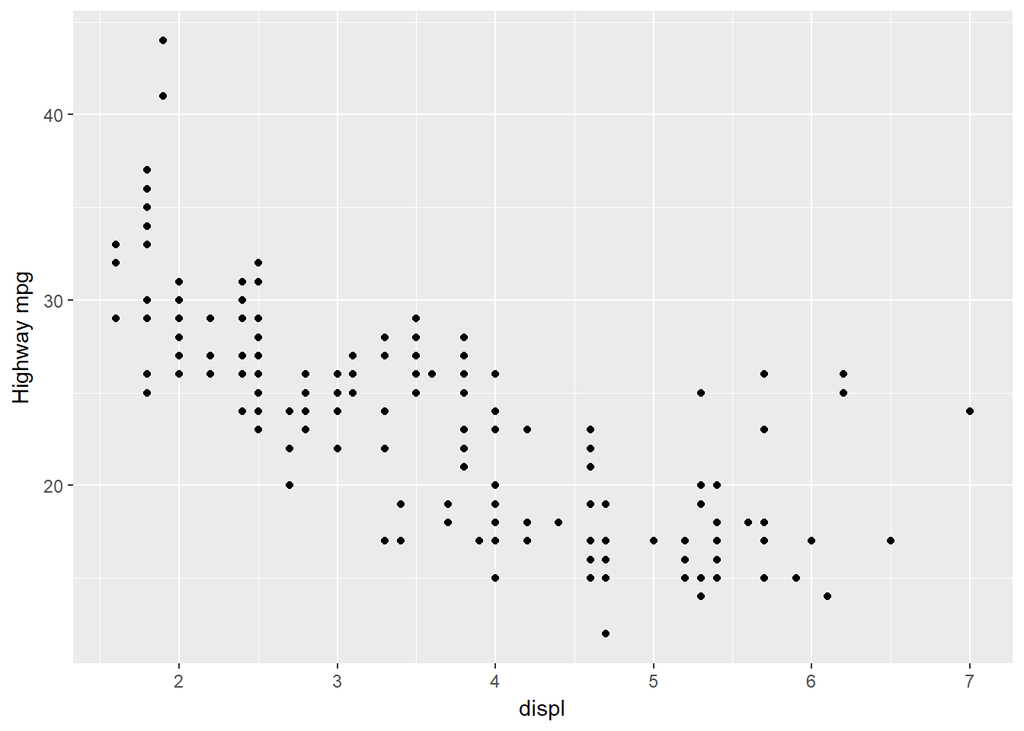

```r
ggplot(mpg, aes(displ, hwy)) +
  geom_point() +
  ylab("Highway mpg")
```

```r
ggplot(mpg, aes(y = displ, x = class)) +
scale_y_continuous("Displacement (l)") +
scale_x_discrete("Car type") +
scale_x_discrete("Type of car") +
scale_colour_discrete() +
geom_point(aes(colour = drv)) +
scale_colour_discrete("Drive\ntrain")
```

This can be simplified down to:

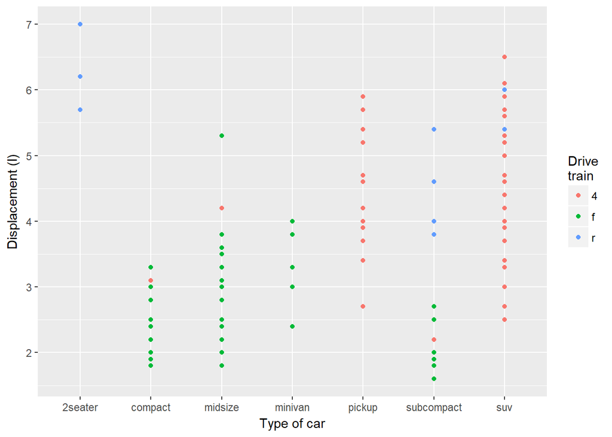

```r
ggplot(mpg, aes(class, displ)) +
  geom_point(aes(color = drv)) +
  labs(x = "Type of car", y = "Displacement (l)", colour = "Drive\ntrain")
```

## *Exercises 6.3.3 *Question 1* Recreate the following graphic: Adjust the y axis label so that the parentheses are the right size.

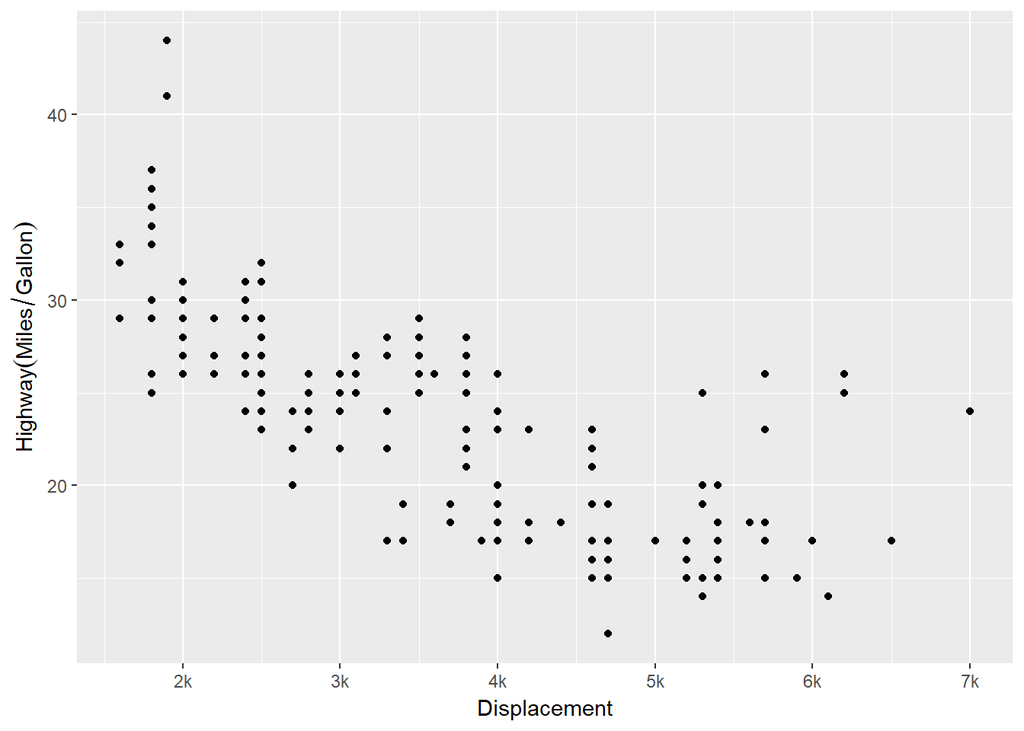

```r
ggplot(mpg, aes(displ, hwy)) +
  geom_point() +
  scale_x_continuous("Displacement",
                     breaks = c(2,3,4,5,6,7),
                     labels = c("2k", "3k", "4k", "5k", "6k", "7k")) +
  scale_y_continuous(quote(Highway (Miles/Gallon)))
```

*Question 2* List the three different types of object you can supply to the breaks argument. How do breaks and labels differ?

Breaks takes one of the followings as input: -NULL for no breaks -waiver() for the default breaks computed by the transformation object -A numeric vector of positions -A function that takes the limits as input and returns breaks as output

Labels takes one of the followings as input: -NULL for no labels -waiver() for the default computed by the transformation object -A character vector giving labels (must be same length as breaks) -A function that takes the breaks as input and returns labels as output

*Question 3* Recreate the following plot:

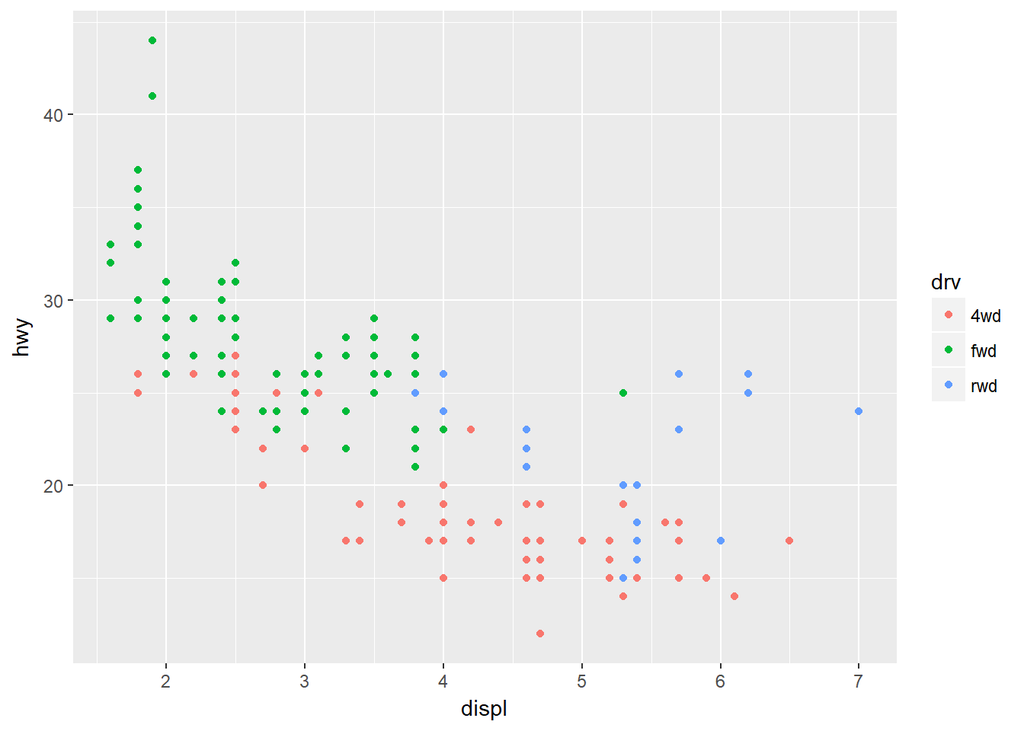

```r
ggplot(mpg, aes(displ, hwy, color = drv)) +
  geom_point() +
  scale_color_discrete(labels = c("4wd", "fwd", "rwd"))
```

*Question 4* What label function allows you to create mathematical expressions?What label function converts 1 to 1st, 2 to 2nd, and so on?

quote() to create mathematical expressions. Type: scales::format and up and down arrows to check: labels = scales::ordinal_format() to convert to 1st, 2nd, 3rd and so on.

*Question 5* What are the three most important arguments that apply to both axes and legends? What do they do? Compare and contrast their operation for axes vs. legends. Maybe labs()? Not sure what three most important means.

## *Exercises 6.4.4*

*Question 1* How do you make legends appear to the left of the plot? theme(legend.position = “left”)

*Question 2* What’s gone wrong with this plot? How could you fix it?

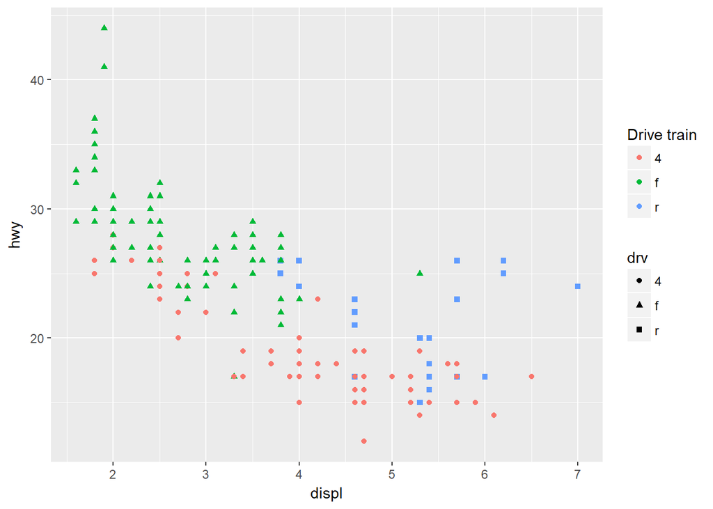

```r
ggplot(mpg, aes(displ, hwy)) +
geom_point(aes(colour = drv, shape = drv)) +
scale_colour_discrete("Drive train")
```

The plot created two legends on the right-hand side, where you could just use one.

Here, quoting from the book:“In order for legends to be merged, they must have the same name. So if you change the name of one of the scales, you’ll need to change it for all of them.”

As a result, here, the original plot sets only colour with new name, while shape doesn’t have the same new name, the result is that these two legends cannot merge. There are two ways to fix this plot:

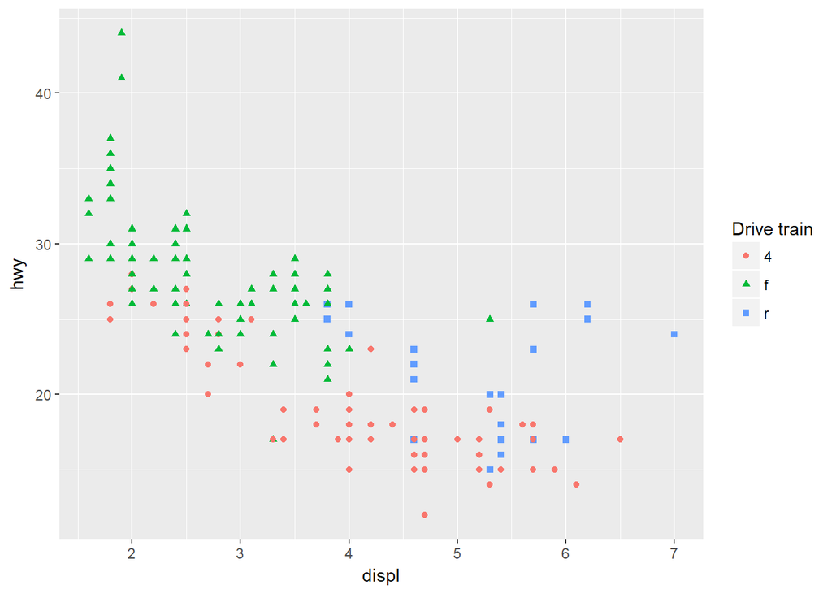

```r
ggplot(mpg, aes(displ, hwy)) +
geom_point(aes(color = drv, shape = drv)) +
  labs(color = "Drive train", shape = "Drive train")
```

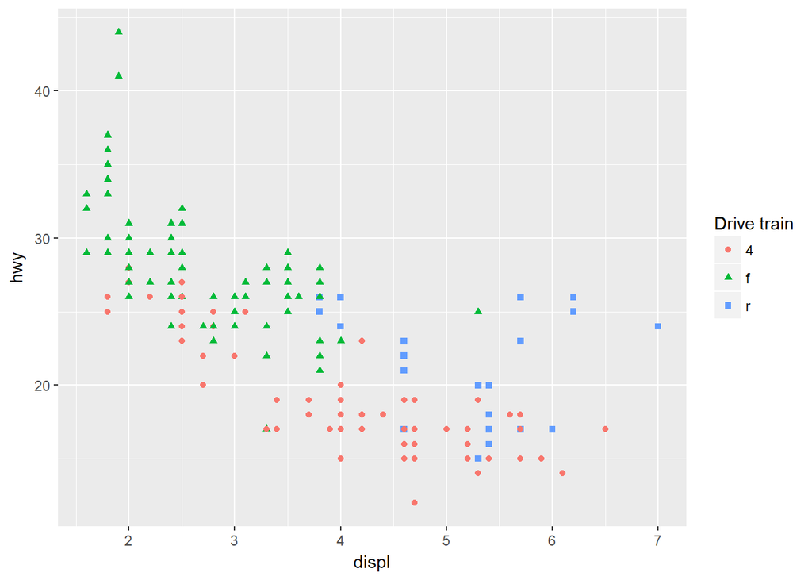

```r
ggplot(mpg, aes(displ, hwy)) +
  geom_point(aes(colour = drv, shape = drv)) +
  scale_colour_discrete("Drive train") +
  scale_shape_discrete("Drive train")
```

*Question 3* Can you recreate the code for this plot?

Answers are above in Question 2 answer.

## *Exercises 6.5.1*

*Question 1* The following code creates two plots of the mpg dataset. Modify the code so that the legend and axes match, without using facetting!

```r
fwd <- subset(mpg, drv == "f")
rwd <- subset(mpg, drv == "r")
ggplot(fwd, aes(displ, hwy, colour = class)) + geom_point()
ggplot(rwd, aes(displ, hwy, colour = class)) + geom_point()
```

We can also set the xlim and ylim so that both plots have the same axes scales. But this is optional.

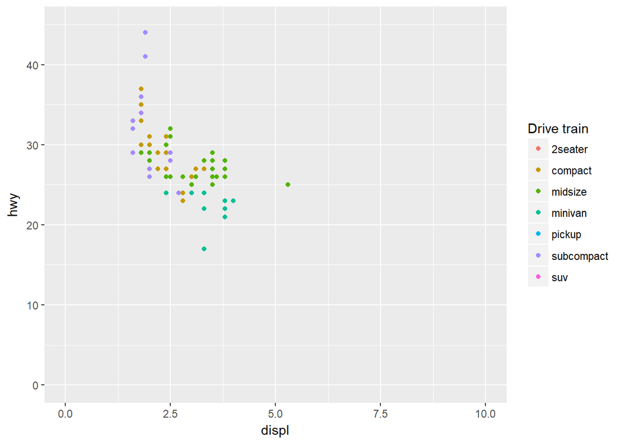

```r
fwd <- subset(mpg, drv == "f")
rwd <- subset(mpg, drv == "r")
ggplot(fwd, aes(displ, hwy, colour = class)) +
  geom_point() +
  scale_color_discrete("Drive train") +
  xlim(0, 10) +
  ylim(0, 45) +
  expand_limits(color = c("2seater", "compact", "midsize", "minivan",
                                   "pickup", "subcompact", "suv"))
```

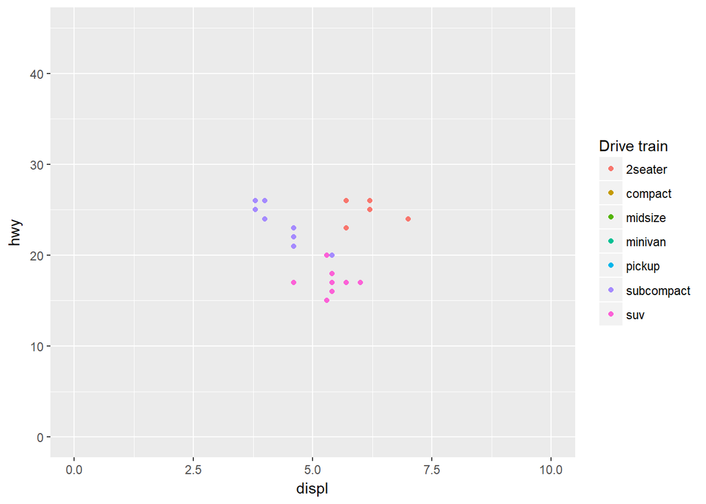

```r
ggplot(rwd, aes(displ, hwy, colour = class)) +
  geom_point() +
  scale_color_discrete("Drive train")+
  xlim(0, 10) +
  ylim(0, 45) +
  expand_limits(color = c("2seater", "compact", "midsize", "minivan",
                                   "pickup", "subcompact", "suv"))
```

*Question 2* What does expand limits() do and how does it work? Read the source code.

Sometimes you may want to ensure limits include a single value, for all panels or all plots. This function is a thin wrapper around geom_blank that makes it easy to add such values.

expand_limits() solves the first question.

*Question 3* What happens if you add two xlim() calls to the same plot? Why?

Use question 1’s plot as an example, let’s test what happens when we add two xlim() calls.

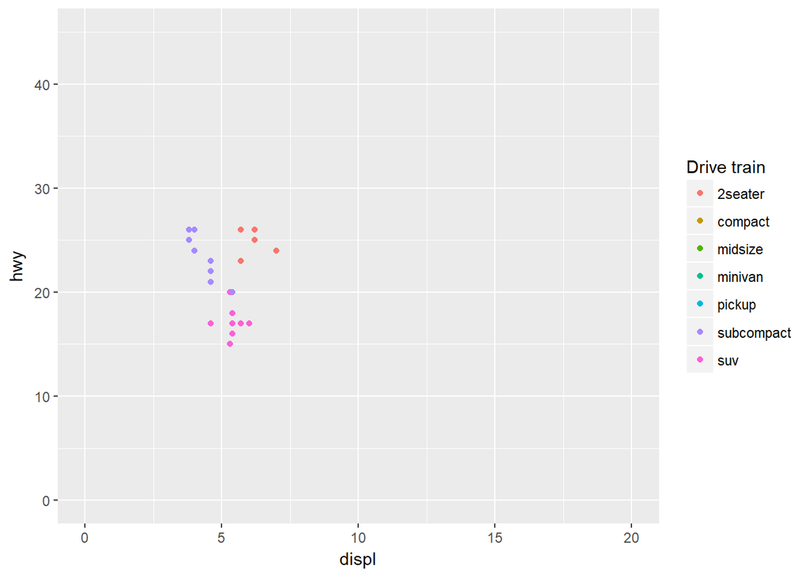

```r
ggplot(rwd, aes(displ, hwy, colour = class)) +
  geom_point() +
  scale_color_discrete("Drive train")+
  xlim(0, 10) +
  xlim(0, 20) +
  ylim(0, 45) +
  expand_limits(color = c("2seater", "compact", "midsize", "minivan",
                                   "pickup", "subcompact", "suv"))
```

The result is that, the second xlim(0, 20) call overrides the first xlim(0, 10) call. As a result, the finished plot has an x-axis ranging from 0 to 20 instead of from 0 to 10.

*Question 4* What does scale x continuous(limits = c(NA, NA)) do? Let’s use the same plot:

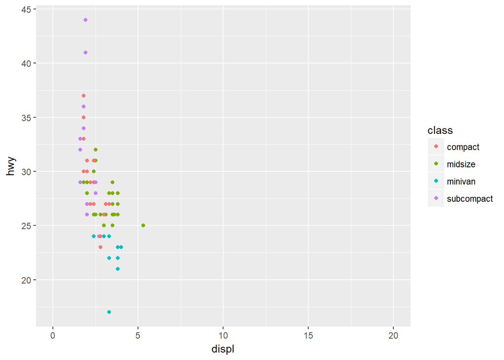

```r
ggplot(fwd, aes(displ, hwy, colour = class)) +
  geom_point() +
  xlim(0, 20)
```

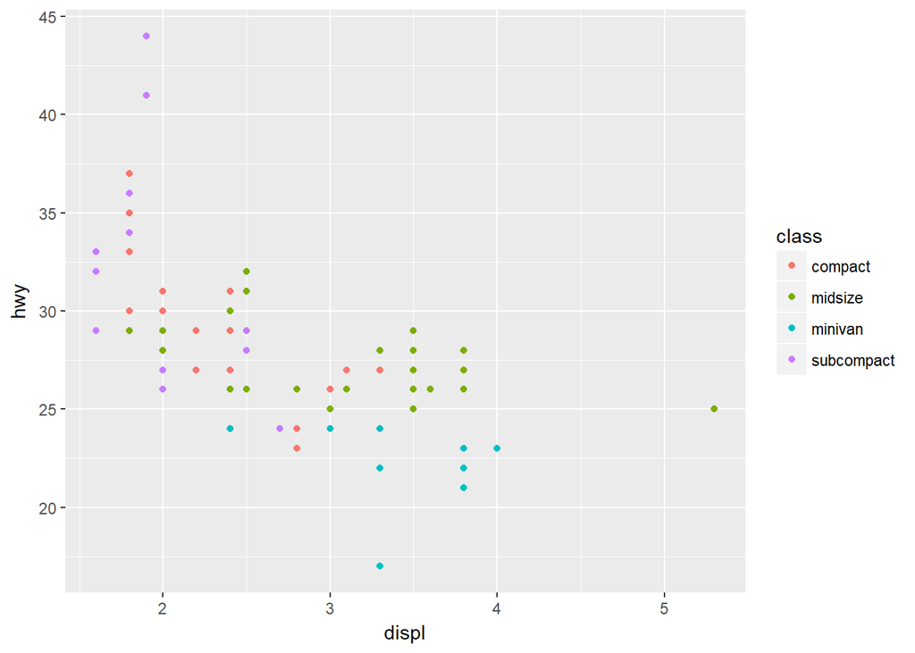

```r
ggplot(fwd, aes(displ, hwy, colour = class)) +
  geom_point() +
  xlim(0, 20) +
  scale_x_continuous(limits = c(NA, NA))
```

This overrides the existing xlim() on the plot. So there is no more limits from xlim().

## *Exercises 6.6.5*

*Question 1* Compare and contrast the four continuous colour scales with the four discrete scales.

Please refer to the textbook.

*Question 2* Explore the distribution of the built-in colors() using the luv colours dataset.

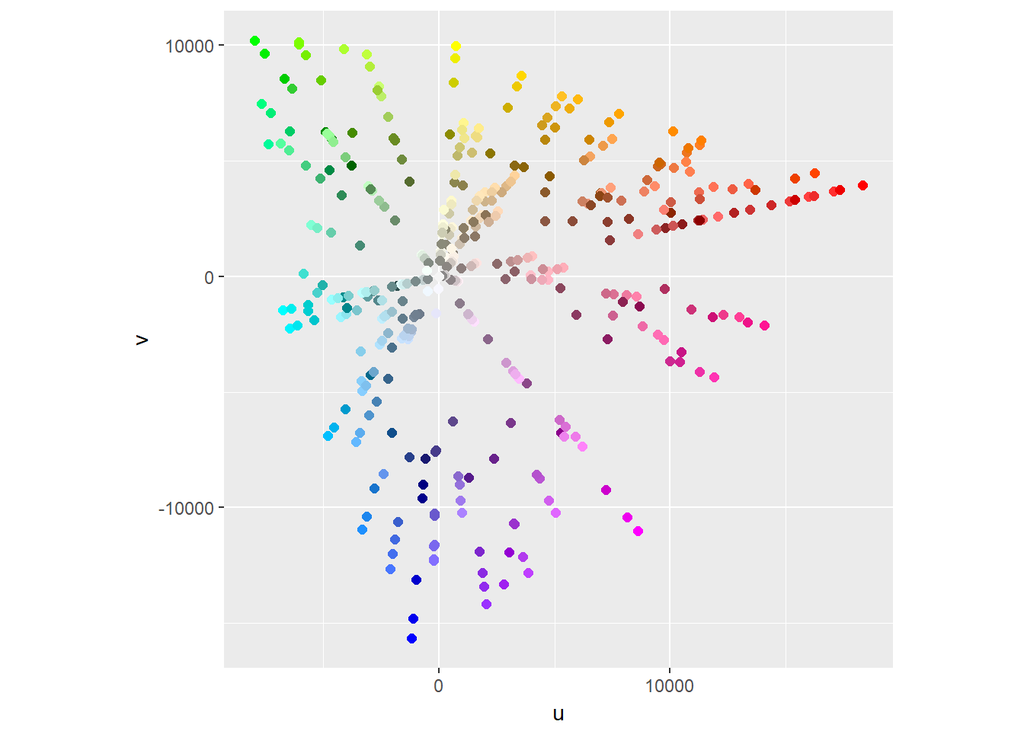

```r
color_df <- colors()

ggplot(luv_colours, aes(u, v)) +
  geom_point(aes(color = color_df), size = 2) +
  scale_color_identity() +
  coord_equal()
```